# Lab 6 - Spatial dependence

# Introduction

In this lab we are going to be assessing and quantifying patterns of spatial dependence in the vegetation data associated with your prickly-pear example from last lab. Within the same 50 m X 50 m square sampling area in which prickly pear locations were marked, vegetation height were taken systematically throughout the plot at sampling points spaced 2 m apart. We will be using the data to interpret spatial dependence of the vegetation height data and then create a map of vegetation height.

First let’s load the packages we need today. We’re going to be introducing some new ones, including pgirmess and ncf, both of which offer functionality for calculating correlograms through slightly different approaches. We also introduce the geoR and gstat packages for building variograms.

```r
rm(list=ls())

require(tidyverse)
require(pgirmess)
require(ncf)
library(geoR)
```

### Raw data

Let’s bring in and examine the raw data briefly.

```r
vegMatrix = read.csv("https://raw.githubusercontent.com/ValenteJJ/SpatialEcology/main/Week5/cactus_matrix.csv")
head(vegMatrix)
```

|  | x | y | Height |
| --- | --- | --- | --- |
| 1 | 0 | 0 | 35 |
| 2 | 0 | 2 | 65 |
| 3 | 0 | 4 | 75 |
| 4 | 0 | 6 | 60 |
| 5 | 0 | 8 | 80 |
| 6 | 0 | 10 | 20 |

What we have is a matrix of values that contains 3 columns, one representing x coordinates, one representing y coordinats, and the third representing vegetation height. Vegetation height was sampled in this system in a 2-m grid pattern, so there are 676 points (26-by-26 grid). We can plot them to get an initial sense of how the values are distributed in space.

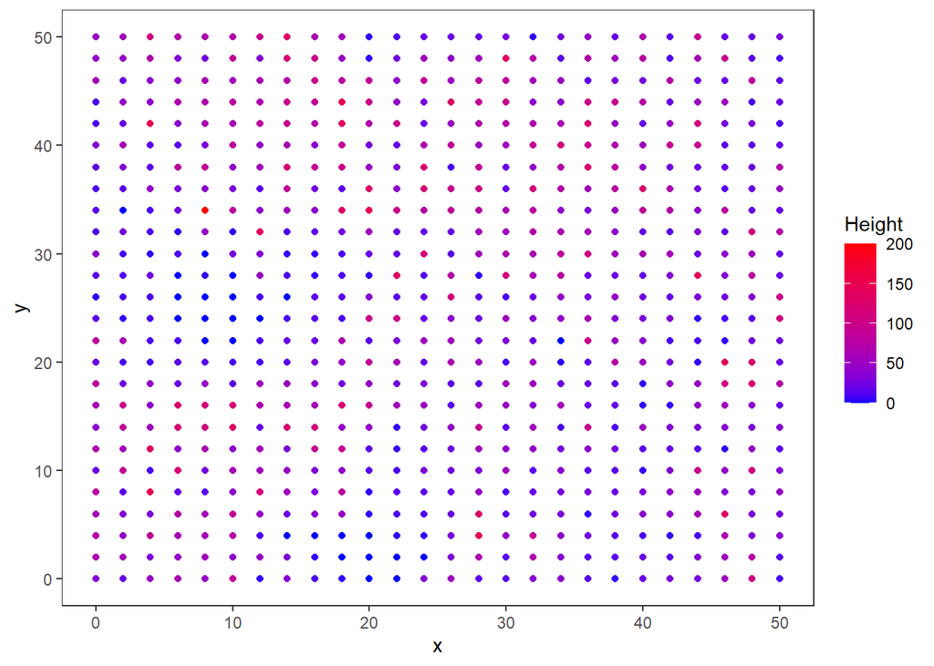

```r
ggplot(vegMatrix, aes(x=x, y=y, color=Height))+
  geom_point()+
  theme_bw()+
  theme(panel.grid=element_blank())+
  scale_color_gradient(low='blue', high='red')
```

# Correlograms

Recall that correlograms are going to plot the correlation between values of points based on their distance apart. We’re going to use two different packages to create correlograms because they vary in the way they estimate statistical significance.

### pgirmess package for normal approximation

The first thing we’re going to need to do is create a matrix of distances among all of the points.

```r
coords = cbind(vegMatrix$x, vegMatrix$y)
colnames(coords) = c('x', 'y')
distMat = as.matrix(dist(coords))
```

Generally we limit our assessment of spatial dependence to about 1/2 to 2/3 of the total distance observed. Beyond that you start getting sample sizes that are too small for evaluation.

```r
maxDist = (2/3) * max(distMat)
```

Now we can run the correlog function to create our correlogram. We need to input our coordinates, the veg heights associated with those points, and the number of bins into which we want to divide our distances, and specify that we want a two-sided statistical test of significance (i.e., testing for positive and negative spatial dependence).

```r
correlogPgirmess = pgirmess::correlog(coords, vegMatrix$Height, method='Moran', nbclass=14, alternative = 'two.sided')

round(correlogPgirmess, 2)
```

```
## Moran I statistic
##       dist.class  coef p.value     n
##  [1,]       4.45  0.19    0.00 21692
##  [2,]       9.36  0.08    0.00 37708
##  [3,]      14.27 -0.01    0.22 51132
##  [4,]      19.18 -0.04    0.00 55500
##  [5,]      24.09 -0.02    0.00 61012
##  [6,]      28.99 -0.01    0.12 58540
##  [7,]      33.90 -0.03    0.00 54440
##  [8,]      38.81 -0.02    0.01 47204
##  [9,]      43.72 -0.01    0.60 32748
## [10,]      48.63 -0.01    0.56 22604
## [11,]      53.53 -0.01    0.67  9100
## [12,]      58.44 -0.03    0.44  3460
## [13,]      63.35 -0.11    0.04  1020
## [14,]      68.26 -0.07    0.75   140
```

So we can see that we have divided the distances into 14 roughly equal distance bins, calculated Moran’s I for each of those distance bins, and assessed statistical significance using a normal approximation (i.e., assuming the residuals from the regression of nearby values on the local value are normally distributed). So let’s plot this correlogram.

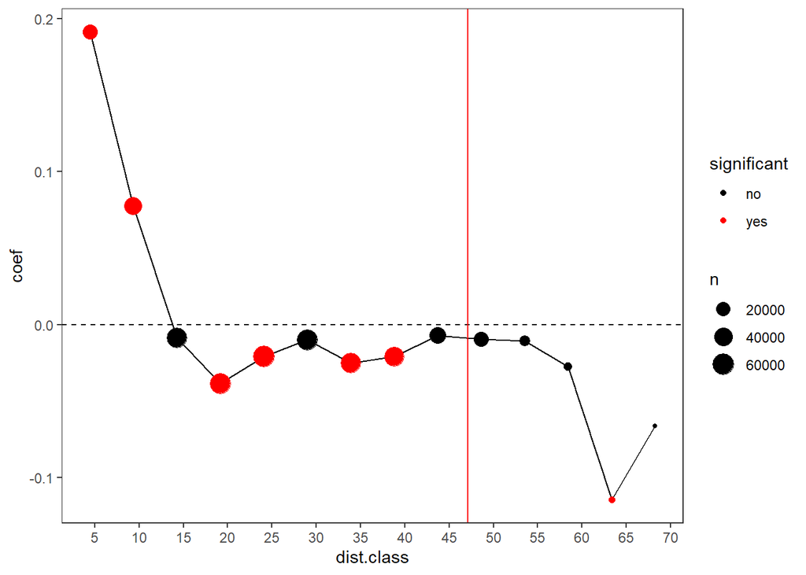

```r
tmp = data.frame(correlogPgirmess) %>%
  mutate(significant = ifelse(p.value < 0.05, 'yes', 'no'))

ggplot(tmp, aes(x=dist.class, y=coef))+
  geom_line()+
  geom_point(aes(color=significant, size=n))+
  scale_color_manual(values=c('black', 'red'))+
  theme_bw()+
  theme(panel.grid=element_blank())+
  geom_hline(yintercept=0, linetype='dashed')+
  geom_vline(xintercept=maxDist, color='red')+
  scale_x_continuous(breaks=seq(0, 75, 5))
```

We can see some clear evidence for positive spatial autocorrelation in vegetation height out to about 10 m, with some evidence of negative spatial autocorrelation at moderate distances.

**REMEMBER the difference between statistical significance and biological significance**

### ncf package for Monte Carlo permutations

Using a normal approximation to evaluate statistical significance in the various distance bins has its limitations. Namely, the assumption may not be met. The ncf package takes a different approach by using Monte Carlo permutations to ask of the correlation observed in our data is significantly different than what we would expect if the values were randomly distributed in space.

```r
correlogNcf = ncf::correlog(x = vegMatrix$x, y=vegMatrix$y, z=vegMatrix$Height, increment=5, resamp=100)
```

```
## 10  of  100
20  of  100
30  of  100
40  of  100
50  of  100
60  of  100
70  of  100
80  of  100
90  of  100
100  of  100
```

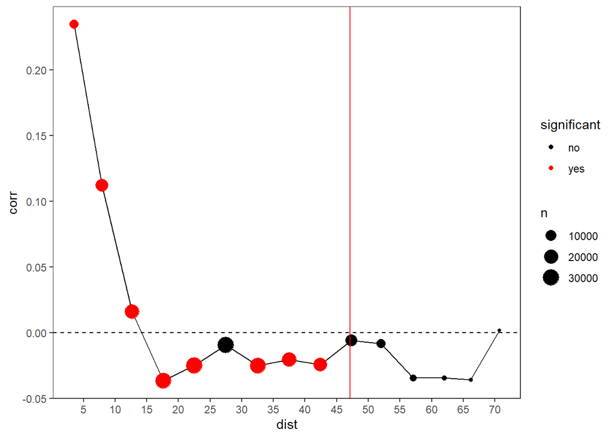

```r
tmp = cbind(correlogNcf$n,
            correlogNcf$mean.of.class,
            correlogNcf$correlation,
            correlogNcf$p) %>%
  data.frame() %>%
  set_names(c('n', 'dist', 'corr', 'p')) %>%
  mutate(significant = ifelse(p < 0.05, 'yes', 'no'))

ggplot(tmp, aes(x=dist, y=corr))+
  geom_line()+
  geom_point(aes(color=significant, size=n))+
  scale_color_manual(values=c('black', 'red'))+
  theme_bw()+
  theme(panel.grid=element_blank())+
  geom_hline(yintercept=0, linetype='dashed')+
  geom_vline(xintercept=maxDist, color='red')+
  scale_x_continuous(breaks=seq(0, 75, 5))
```

The main differences between pgirmess and ncf are:

1. pgirmess relies on a normal approximation to evaluate statistical significance while ncf relies on Monte Carlo permutations.
2. In pgirmess you specify a number of distance bands, but in ncf you specify the actual width of those bands.

# Variograms

We’re mostly going to focus on the geoR package because it allows us to compare model-based variograms to one another using likelihood approaches (AIC). It also provides Monte Carlo approaches. Let’s start by creating a geoR object and plotting it.

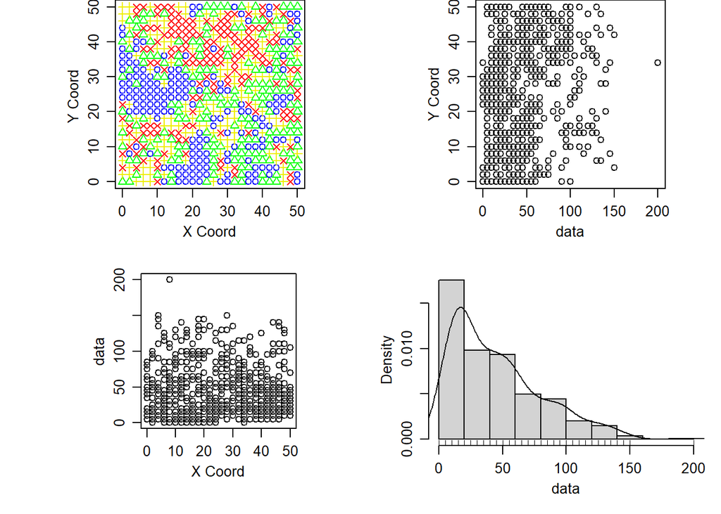

```r
#Note that this is automatically considering the first two columns to be x and y and the third column to be z.
geoVeg = as.geodata(vegMatrix)
plot(geoVeg)
```

The plot function gave us 4 plots for visualizing these data. The first is a color map showing the low values of vegetation height in blue and the high values in red. The second and third values show the distribution of veg height values stratified across x and y coordinates. The final figure shows a histogram of the veg height values.

Now we can build a variogram from this object. Again, here we are specifying that we don’t really want to look beyond 2/3 of the distance in the data, and telling it to build the variogram based on distance bins of 3 m.

```r
empGeor = variog(geoVeg, max.dist=maxDist, breaks=seq(0, maxDist, by=3))
```

```
## variog: computing omnidirectional variogram
```

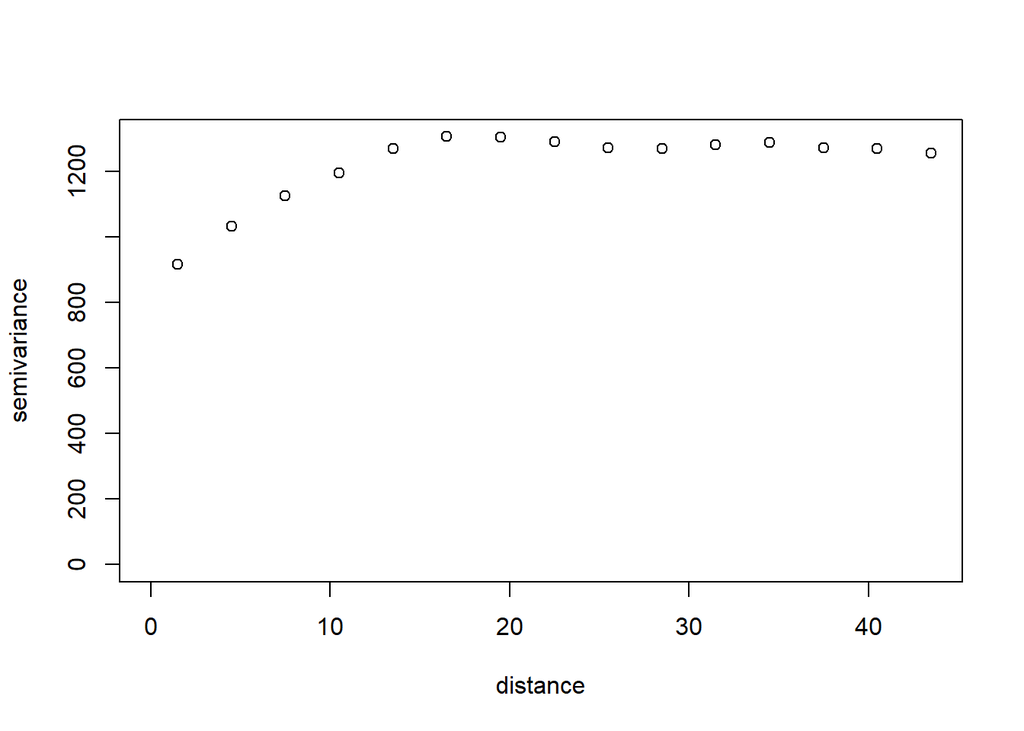

```r
plot(empGeor)
```

### Evidence for anisotropy?

```r
emp4Geor = variog4(geoVeg, max.dist=maxDist, direction = c(0, pi/4, pi/2, 3*pi/4))
```

```
## variog: computing variogram for direction = 0 degrees (0 radians)
##         tolerance angle = 22.5 degrees (0.393 radians)
## variog: computing variogram for direction = 45 degrees (0.785 radians)
##         tolerance angle = 22.5 degrees (0.393 radians)
## variog: computing variogram for direction = 90 degrees (1.571 radians)
##         tolerance angle = 22.5 degrees (0.393 radians)
## variog: computing variogram for direction = 135 degrees (2.356 radians)
##         tolerance angle = 22.5 degrees (0.393 radians)
## variog: computing omnidirectional variogram
```

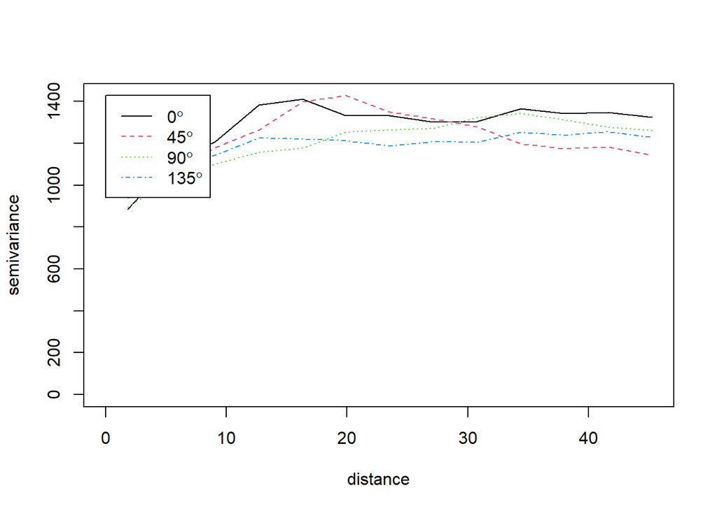

```r
plot(emp4Geor)
```

Here I would superficially conclude that the spatial covariance patterns are relatively similar in all directions.

### Fitting variogram models

Recall that we discussed several theoretical models one could use to represent the pattern in a variogram. Here we’re going to fit two of those empirical models and compare them using AIC. Let’s start with an exponential model.

```r
mlExp = likfit(geoVeg, cov.model='exp', ini=c(700, 10))
```

[output not shown]

```r
summary(mlExp)
```

```
## Summary of the parameter estimation
## -----------------------------------
## Estimation method: maximum likelihood
##
## Parameters of the mean component (trend):
##    beta
## 43.0713
##
## Parameters of the spatial component:
##    correlation function: exponential
##       (estimated) variance parameter sigmasq (partial sill) =  504.6
##       (estimated) cor. fct. parameter phi (range parameter)  =  5.883
##    anisotropy parameters:
##       (fixed) anisotropy angle = 0  ( 0 degrees )
##       (fixed) anisotropy ratio = 1
##
## Parameter of the error component:
##       (estimated) nugget =  732
##
## Transformation parameter:
##       (fixed) Box-Cox parameter = 1 (no transformation)
##
## Practical Range with cor=0.05 for asymptotic range: 17.62418
##
## Maximised Likelihood:
##    log.L n.params      AIC      BIC
##  "-3298"      "4"   "6603"   "6621"
##
## non spatial model:
##    log.L n.params      AIC      BIC
##  "-3368"      "2"   "6739"   "6748"
##
## Call:
## likfit(geodata = geoVeg, ini.cov.pars = c(700, 10), cov.model = "exp")
```

This output is telling us a lot of things. First, we’re seeing an AIC value for the spatial model we fit and a comparable value for a non-spatial model that assumes a constant variance that does not change with lag distance. Here we can see that there is clear evidence for spatial covariance, given that the AIC for the constant model is > 100 units greater. We’re also seeing estimates for the range, nugget, and partial sill values for the fitted model. For some models (like exponential), we also see an estimate for the “practical range” which approximates the range distance at which the variogram asymptotes.

Next let’s fit a spherical theoretical model.

```r
mlSph = likfit(geoVeg, cov.model='sph', ini=c(700, 10))
```

[output not shown]

```r
summary(mlSph)
```

```
## Summary of the parameter estimation
## -----------------------------------
## Estimation method: maximum likelihood
##
## Parameters of the mean component (trend):
##    beta
## 43.3481
##
## Parameters of the spatial component:
##    correlation function: spherical
##       (estimated) variance parameter sigmasq (partial sill) =  451.5
##       (estimated) cor. fct. parameter phi (range parameter)  =  16.71
##    anisotropy parameters:
##       (fixed) anisotropy angle = 0  ( 0 degrees )
##       (fixed) anisotropy ratio = 1
##
## Parameter of the error component:
##       (estimated) nugget =  814.4
##
## Transformation parameter:
##       (fixed) Box-Cox parameter = 1 (no transformation)
##
## Practical Range with cor=0.05 for asymptotic range: 16.70779
##
## Maximised Likelihood:
##    log.L n.params      AIC      BIC
##  "-3298"      "4"   "6604"   "6622"
##
## non spatial model:
##    log.L n.params      AIC      BIC
##  "-3368"      "2"   "6739"   "6748"
##
## Call:
## likfit(geodata = geoVeg, ini.cov.pars = c(700, 10), cov.model = "sph")
```

Again, we can see that the spatial model is much better than the constant model. When we compare the two fitted spatial models to one another:

```r
AIC(mlExp, mlSph)
```

|  | df | AIC |
| --- | --- | --- |
| mlExp | 4 | 6603.375 |
| mlSph | 4 | 6603.830 |

We see that the AIC value of the exponential model is slightly lower than that of the spherical model, although the difference is relatively trivial. Finally, we can plot our fitted theoretical variograms on top of the empirical variogram.

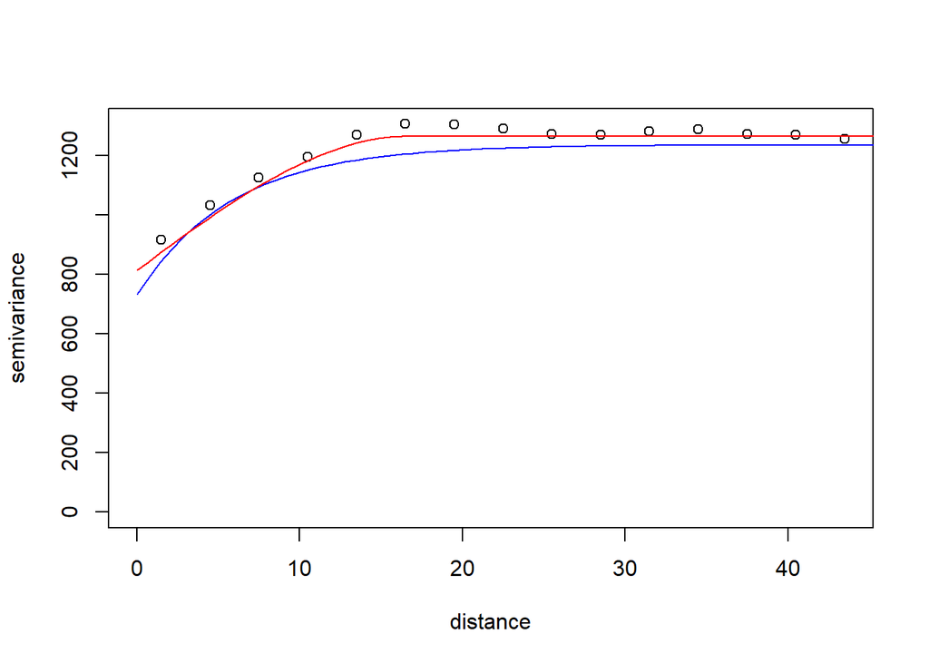

```r
plot(empGeor)
lines(mlExp, col='blue')
lines(mlSph, col='red')
```

As always, we are generally interested to know whether the degree of spatial dependence we are seeing here differs significantly from what might be expected if the vegetation height values were randomly distributed. For that, we can use the variog.mc.env() function in geoR. This calculates an envelope for an empirical variogram by permuting the height values across space. Here we are telling the function to permute values over the geoVeg data set and specifying the empirical variogram that we calculated from the geoVeg dataset.

```r
empEnv = variog.mc.env(geoVeg, obj.var=empGeor, nsim=99)
```

```
## variog.env: generating 99 simulations by permutating data values
## variog.env: computing the empirical variogram for the 99 simulations
## variog.env: computing the envelops
```

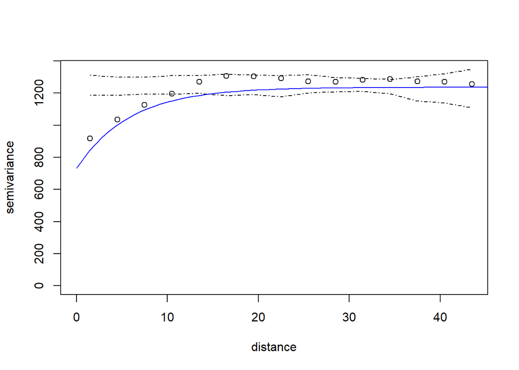

```r
plot(empGeor, envelope=empEnv)
lines(mlExp, col='blue')
```

Now we’re seeing our envelope (dashed lines) plotted with the empirical variogram and the fitted variogram model. Note that we are seeing evidence for significant spatial dependence up to about 10 m.

# Kriging

Now that we have a fitted variogram, we can interpolate values to places that were not sampled using kriging. This is analogous to fitting a model and then outputting predicted values to new covariate combinations.

```r
newGrid1m = expand.grid(0:max(vegMatrix$x), 0:max(vegMatrix$y))

krigGeoRExp = krige.conv(geoVeg, locations=newGrid1m, krige=krige.control(cov.pars=c(mlExp$cov.pars[1], mlExp$cov.pars[2]), nugget=mlExp$nugget, cov.model='exp', type.krige='OK'))
```

```
## krige.conv: model with constant mean
## krige.conv: Kriging performed using global neighbourhood
```

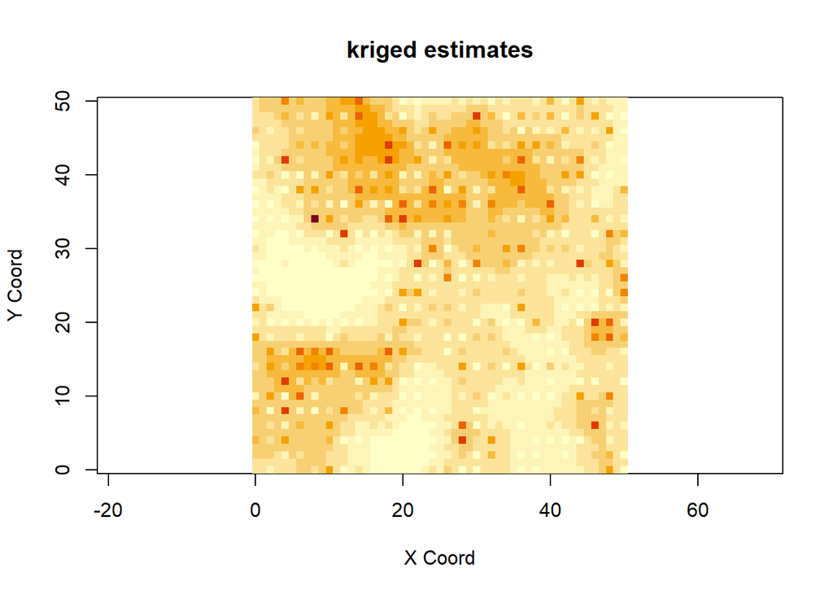

```r
image(krigGeoRExp, main='kriged estimates')
```

So here we are running krige.cov(), which performs spatial predictions. We input our geodata object, our new locations to which we want to predict values, parameters based on our fitted variogram, and specify a type of kriging model to use. Here we’re just specifying ordinary kriging. The result is a smoothed map of predicted veg heights. We can also output the uncertainty in the predictions at those points in space.

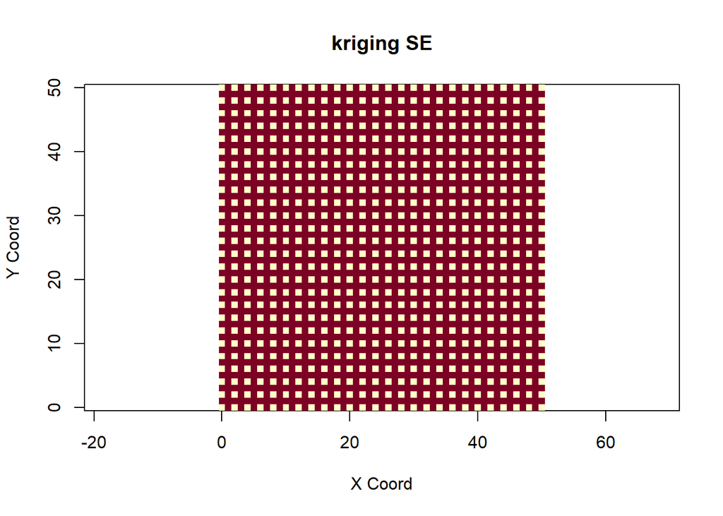

```r
image(krigGeoRExp, val=sqrt(krigGeoRExp$krige.var), main='kriging SE')
```